# Optimal Treatment Analysis

## Outcome Variable

**Outcome Variable:** haz

## Predictor Variables

**Intervention Variable:** earlybf

**Adjustment Set:**

- arm
- sex
- W_mage
- meducyrs
- feducyrs
- hhwealth_quart
- hfoodsec
- W_mhtcm
- W_mwtkg
- W_mbmi
- vagbrth
- W_gagebrth
- W_birthwt
- W_birthlen
- W_nrooms
- W_nchldlt5
- brthmon
- W_parity
- impfloor
- impsan
- safeh20
- delta_W_mage
- delta_meducyrs
- delta_feducyrs
- delta_hhwealth_quart
- delta_hfoodsec
- delta_W_mhtcm
- delta_W_mwtkg
- delta_W_mbmi
- delta_vagbrth
- delta_W_gagebrth
- delta_W_birthwt
- delta_W_birthlen
- delta_W_nrooms
- delta_W_nchldlt5
- delta_brthmon
- delta_W_parity
- delta_impfloor
- delta_impsan
- delta_safeh20

## Stratifying Variables

The analysis was stratified on these variable(s):

- agecat
- studyid
- country

## Data Summary

| agecat | studyid | country | earlybf | n_cell | n |
| --- | --- | --- | --- | --- | --- |
| Birth | ki0047075b-MAL-ED | BANGLADESH | 1 | 147 | 230 |
| Birth | ki0047075b-MAL-ED | BANGLADESH | 0 | 83 | 230 |
| Birth | ki0047075b-MAL-ED | BRAZIL | 1 | 28 | 65 |
| Birth | ki0047075b-MAL-ED | BRAZIL | 0 | 37 | 65 |
| Birth | ki0047075b-MAL-ED | INDIA | 1 | 32 | 46 |
| Birth | ki0047075b-MAL-ED | INDIA | 0 | 14 | 46 |
| Birth | ki0047075b-MAL-ED | NEPAL | 1 | 14 | 27 |
| Birth | ki0047075b-MAL-ED | NEPAL | 0 | 13 | 27 |
| Birth | ki0047075b-MAL-ED | PERU | 1 | 175 | 233 |
| Birth | ki0047075b-MAL-ED | PERU | 0 | 58 | 233 |
| Birth | ki0047075b-MAL-ED | SOUTH AFRICA | 1 | 69 | 111 |
| Birth | ki0047075b-MAL-ED | SOUTH AFRICA | 0 | 42 | 111 |
| Birth | ki0047075b-MAL-ED | TANZANIA, UNITED REPUBLIC OF | 1 | 111 | 125 |
| Birth | ki0047075b-MAL-ED | TANZANIA, UNITED REPUBLIC OF | 0 | 14 | 125 |
| Birth | ki1000109-EE | PAKISTAN | 1 | 44 | 229 |
| Birth | ki1000109-EE | PAKISTAN | 0 | 185 | 229 |
| Birth | ki1000304b-SAS-CompFeed | INDIA | 1 | 86 | 1207 |
| Birth | ki1000304b-SAS-CompFeed | INDIA | 0 | 1121 | 1207 |
| Birth | ki1017093c-NIH-Crypto | BANGLADESH | 1 | 634 | 732 |
| Birth | ki1017093c-NIH-Crypto | BANGLADESH | 0 | 98 | 732 |
| Birth | ki1113344-GMS-Nepal | NEPAL | 1 | 180 | 632 |
| Birth | ki1113344-GMS-Nepal | NEPAL | 0 | 452 | 632 |
| Birth | ki1126311-ZVITAMBO | ZIMBABWE | 1 | 6556 | 12354 |
| Birth | ki1126311-ZVITAMBO | ZIMBABWE | 0 | 5798 | 12354 |
| Birth | kiGH5241-JiVitA-3 | BANGLADESH | 1 | 261 | 26569 |
| Birth | kiGH5241-JiVitA-3 | BANGLADESH | 0 | 26308 | 26569 |
| Birth | kiGH5241-JiVitA-4 | BANGLADESH | 1 | 1912 | 2823 |
| Birth | kiGH5241-JiVitA-4 | BANGLADESH | 0 | 911 | 2823 |
| 6 months | ki0047075b-MAL-ED | BANGLADESH | 1 | 147 | 240 |
| 6 months | ki0047075b-MAL-ED | BANGLADESH | 0 | 93 | 240 |

[output cut: 52 more lines]

The following strata were considered:

- agecat: 24 months, studyid: ki0047075b-MAL-ED, country: BANGLADESH
- agecat: 24 months, studyid: ki0047075b-MAL-ED, country: BRAZIL
- agecat: 24 months, studyid: ki0047075b-MAL-ED, country: INDIA
- agecat: 24 months, studyid: ki0047075b-MAL-ED, country: NEPAL
- agecat: 24 months, studyid: ki0047075b-MAL-ED, country: PERU
- agecat: 24 months, studyid: ki0047075b-MAL-ED, country: SOUTH AFRICA
- agecat: 24 months, studyid: ki0047075b-MAL-ED, country: TANZANIA, UNITED REPUBLIC OF
- agecat: 24 months, studyid: ki1000109-EE, country: PAKISTAN
- agecat: 24 months, studyid: ki1017093c-NIH-Crypto, country: BANGLADESH
- agecat: 24 months, studyid: ki1113344-GMS-Nepal, country: NEPAL
- agecat: 24 months, studyid: ki1126311-ZVITAMBO, country: ZIMBABWE
- agecat: 24 months, studyid: kiGH5241-JiVitA-3, country: BANGLADESH
- agecat: 24 months, studyid: kiGH5241-JiVitA-4, country: BANGLADESH
- agecat: 6 months, studyid: ki0047075b-MAL-ED, country: BANGLADESH
- agecat: 6 months, studyid: ki0047075b-MAL-ED, country: BRAZIL
- agecat: 6 months, studyid: ki0047075b-MAL-ED, country: INDIA
- agecat: 6 months, studyid: ki0047075b-MAL-ED, country: NEPAL
- agecat: 6 months, studyid: ki0047075b-MAL-ED, country: PERU
- agecat: 6 months, studyid: ki0047075b-MAL-ED, country: SOUTH AFRICA
- agecat: 6 months, studyid: ki0047075b-MAL-ED, country: TANZANIA, UNITED REPUBLIC OF
- agecat: 6 months, studyid: ki1000109-EE, country: PAKISTAN
- agecat: 6 months, studyid: ki1000304b-SAS-CompFeed, country: INDIA
- agecat: 6 months, studyid: ki1017093c-NIH-Crypto, country: BANGLADESH
- agecat: 6 months, studyid: ki1113344-GMS-Nepal, country: NEPAL
- agecat: 6 months, studyid: ki1126311-ZVITAMBO, country: ZIMBABWE
- agecat: 6 months, studyid: kiGH5241-JiVitA-3, country: BANGLADESH
- agecat: 6 months, studyid: kiGH5241-JiVitA-4, country: BANGLADESH
- agecat: Birth, studyid: ki0047075b-MAL-ED, country: BANGLADESH
- agecat: Birth, studyid: ki0047075b-MAL-ED, country: BRAZIL
- agecat: Birth, studyid: ki0047075b-MAL-ED, country: INDIA
- agecat: Birth, studyid: ki0047075b-MAL-ED, country: NEPAL
- agecat: Birth, studyid: ki0047075b-MAL-ED, country: PERU
- agecat: Birth, studyid: ki0047075b-MAL-ED, country: SOUTH AFRICA
- agecat: Birth, studyid: ki0047075b-MAL-ED, country: TANZANIA, UNITED REPUBLIC OF
- agecat: Birth, studyid: ki1000109-EE, country: PAKISTAN
- agecat: Birth, studyid: ki1000304b-SAS-CompFeed, country: INDIA
- agecat: Birth, studyid: ki1017093c-NIH-Crypto, country: BANGLADESH
- agecat: Birth, studyid: ki1113344-GMS-Nepal, country: NEPAL
- agecat: Birth, studyid: ki1126311-ZVITAMBO, country: ZIMBABWE
- agecat: Birth, studyid: kiGH5241-JiVitA-3, country: BANGLADESH
- agecat: Birth, studyid: kiGH5241-JiVitA-4, country: BANGLADESH

### Dropped Strata

Some strata were dropped due to rare outcomes:

- agecat: 24 months, studyid: kiGH5241-JiVitA-3, country: BANGLADESH

## Methods Detail

We’re interested in the causal parameters $E[Y_a]$ for all values of $a \in \mathcal{A}$. These parameters represent the mean outcome if, possibly contrary to fact, we intervened to set all units to have $A=a$. Under the randomization and positivity assumptions, these are identified by the statistical parameters $\psi_a=E_W[E_{Y|A,W}(Y|A=a,W)]$. In addition, we’re interested in the mean of $Y$, $E[Y]$ under no intervention (the observed mean). We will estimate these parameters by using SuperLearner to fit the relevant likelihood factors – $E_{Y|A,W}(Y|A=a,W)$ and $p(A=a|W)$, and then updating our likelihood fit using a joint TMLE.

For unadjusted analyses ($W=\{\}$), initial likelihoods were estimated using Lrnr_glm to estimate the simple $E(Y|A)$ and Lrnr_mean to estimate $p(A)$. For adjusted analyses, a small library containing Lrnr_glmnet, Lrnr_xgboost, and Lrnr_mean was used.

Having estimated these parameters, we will then use the delta method to estimate relative risks and attributable risks relative to a prespecified baseline level of $A$.

# Results Detail

## Results Plots

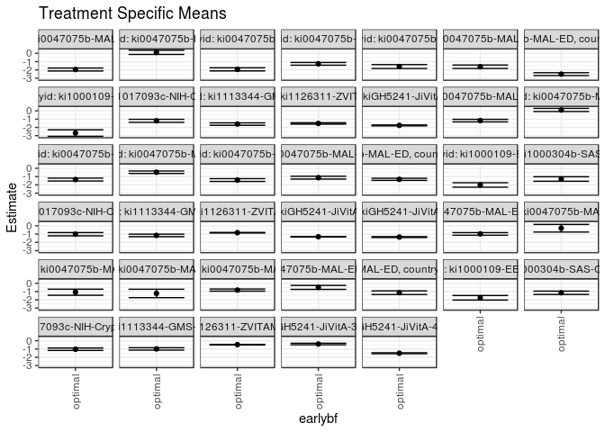

## Results Table

### Parameter: TSM

| agecat | studyid | country | intervention_level | baseline_level | estimate | ci_lower | ci_upper |
| --- | --- | --- | --- | --- | --- | --- | --- |
| Birth | ki0047075b-MAL-ED | BANGLADESH | optimal | observed | -0.9805694 | -1.1397205 | -0.8214183 |
| Birth | ki0047075b-MAL-ED | BRAZIL | optimal | observed | -0.2918768 | -0.7539888 | 0.1702352 |
| Birth | ki0047075b-MAL-ED | INDIA | optimal | observed | -1.0819983 | -1.4480896 | -0.7159070 |
| Birth | ki0047075b-MAL-ED | NEPAL | optimal | observed | -1.2257758 | -1.7331190 | -0.7184327 |
| Birth | ki0047075b-MAL-ED | PERU | optimal | observed | -0.8192908 | -0.9478225 | -0.6907591 |
| Birth | ki0047075b-MAL-ED | SOUTH AFRICA | optimal | observed | -0.4980268 | -0.7375534 | -0.2585002 |
| Birth | ki0047075b-MAL-ED | TANZANIA, UNITED REPUBLIC OF | optimal | observed | -1.1370186 | -1.3561000 | -0.9179372 |
| Birth | ki1000109-EE | PAKISTAN | optimal | observed | -1.7536787 | -2.0293659 | -1.4779915 |
| Birth | ki1000304b-SAS-CompFeed | INDIA | optimal | observed | -1.1469439 | -1.3464953 | -0.9473926 |
| Birth | ki1017093c-NIH-Crypto | BANGLADESH | optimal | observed | -1.0244860 | -1.1720382 | -0.8769338 |
| Birth | ki1113344-GMS-Nepal | NEPAL | optimal | observed | -0.9882274 | -1.1323597 | -0.8440951 |
| Birth | ki1126311-ZVITAMBO | ZIMBABWE | optimal | observed | -0.4702571 | -0.5015159 | -0.4389983 |
| Birth | kiGH5241-JiVitA-3 | BANGLADESH | optimal | observed | -0.3936151 | -0.4858288 | -0.3014014 |
| Birth | kiGH5241-JiVitA-4 | BANGLADESH | optimal | observed | -1.5101947 | -1.5678071 | -1.4525823 |
| 6 months | ki0047075b-MAL-ED | BANGLADESH | optimal | observed | -1.1798191 | -1.3330143 | -1.0266239 |
| 6 months | ki0047075b-MAL-ED | BRAZIL | optimal | observed | 0.1103426 | -0.0794706 | 0.3001559 |
| 6 months | ki0047075b-MAL-ED | INDIA | optimal | observed | -1.3565876 | -1.5320165 | -1.1811586 |
| 6 months | ki0047075b-MAL-ED | NEPAL | optimal | observed | -0.4699313 | -0.6222209 | -0.3176418 |
| 6 months | ki0047075b-MAL-ED | PERU | optimal | observed | -1.4178064 | -1.5892612 | -1.2463516 |
| 6 months | ki0047075b-MAL-ED | SOUTH AFRICA | optimal | observed | -1.1257069 | -1.2960626 | -0.9553511 |
| 6 months | ki0047075b-MAL-ED | TANZANIA, UNITED REPUBLIC OF | optimal | observed | -1.3268802 | -1.4550132 | -1.1987472 |
| 6 months | ki1000109-EE | PAKISTAN | optimal | observed | -2.0102041 | -2.2774718 | -1.7429365 |
| 6 months | ki1000304b-SAS-CompFeed | INDIA | optimal | observed | -1.2918901 | -1.5637679 | -1.0200123 |
| 6 months | ki1017093c-NIH-Crypto | BANGLADESH | optimal | observed | -1.0128824 | -1.2085364 | -0.8172283 |
| 6 months | ki1113344-GMS-Nepal | NEPAL | optimal | observed | -1.1598369 | -1.3096960 | -1.0099778 |
| 6 months | ki1126311-ZVITAMBO | ZIMBABWE | optimal | observed | -0.8345901 | -0.8701357 | -0.7990445 |
| 6 months | kiGH5241-JiVitA-3 | BANGLADESH | optimal | observed | -1.3217988 | -1.3455414 | -1.2980561 |
| 6 months | kiGH5241-JiVitA-4 | BANGLADESH | optimal | observed | -1.3613855 | -1.4120324 | -1.3107386 |
| 24 months | ki0047075b-MAL-ED | BANGLADESH | optimal | observed | -1.9503437 | -2.1290623 | -1.7716251 |
| 24 months | ki0047075b-MAL-ED | BRAZIL | optimal | observed | 0.1210498 | -0.1310624 | 0.3731621 |
| 24 months | ki0047075b-MAL-ED | INDIA | optimal | observed | -1.9308369 | -2.1194316 | -1.7422422 |
| 24 months | ki0047075b-MAL-ED | NEPAL | optimal | observed | -1.2636564 | -1.4260660 | -1.1012468 |
| 24 months | ki0047075b-MAL-ED | PERU | optimal | observed | -1.5908832 | -1.8246667 | -1.3570996 |
| 24 months | ki0047075b-MAL-ED | SOUTH AFRICA | optimal | observed | -1.6121974 | -1.8180143 | -1.4063806 |
| 24 months | ki0047075b-MAL-ED | TANZANIA, UNITED REPUBLIC OF | optimal | observed | -2.5083320 | -2.6836128 | -2.3330511 |
| 24 months | ki1000109-EE | PAKISTAN | optimal | observed | -2.6822651 | -3.0764563 | -2.2880738 |
| 24 months | ki1017093c-NIH-Crypto | BANGLADESH | optimal | observed | -1.2032047 | -1.3841163 | -1.0222932 |
| 24 months | ki1113344-GMS-Nepal | NEPAL | optimal | observed | -1.5963405 | -1.7440973 | -1.4485836 |
| 24 months | ki1126311-ZVITAMBO | ZIMBABWE | optimal | observed | -1.5232968 | -1.6061571 | -1.4404365 |
| 24 months | kiGH5241-JiVitA-4 | BANGLADESH | optimal | observed | -1.7586791 | -1.8119616 | -1.7053966 |

### Parameter: E(Y)

| agecat | studyid | country | intervention_level | baseline_level | estimate | ci_lower | ci_upper |
| --- | --- | --- | --- | --- | --- | --- | --- |
| Birth | ki0047075b-MAL-ED | BANGLADESH | observed | observed | -1.1218261 | -1.2566576 | -0.9869945 |
| Birth | ki0047075b-MAL-ED | BRAZIL | observed | observed | -0.6760000 | -0.9521457 | -0.3998543 |
| Birth | ki0047075b-MAL-ED | INDIA | observed | observed | -1.2221739 | -1.5203945 | -0.9239534 |
| Birth | ki0047075b-MAL-ED | NEPAL | observed | observed | -0.8533333 | -1.2104864 | -0.4961803 |
| Birth | ki0047075b-MAL-ED | PERU | observed | observed | -0.8827897 | -1.0001058 | -0.7654736 |
| Birth | ki0047075b-MAL-ED | SOUTH AFRICA | observed | observed | -0.5709009 | -0.7569265 | -0.3848753 |
| Birth | ki0047075b-MAL-ED | TANZANIA, UNITED REPUBLIC OF | observed | observed | -1.1556000 | -1.3655361 | -0.9456639 |
| Birth | ki1000109-EE | PAKISTAN | observed | observed | -1.8713537 | -2.0647180 | -1.6779894 |
| Birth | ki1000304b-SAS-CompFeed | INDIA | observed | observed | -1.4072245 | -1.4817853 | -1.3326638 |
| Birth | ki1017093c-NIH-Crypto | BANGLADESH | observed | observed | -0.9094945 | -0.9809370 | -0.8380521 |
| Birth | ki1113344-GMS-Nepal | NEPAL | observed | observed | -1.0578481 | -1.1411010 | -0.9745953 |
| Birth | ki1126311-ZVITAMBO | ZIMBABWE | observed | observed | -0.4895257 | -0.5113672 | -0.4676841 |
| Birth | kiGH5241-JiVitA-3 | BANGLADESH | observed | observed | -1.1723268 | -1.2004766 | -1.1441770 |
| Birth | kiGH5241-JiVitA-4 | BANGLADESH | observed | observed | -1.5232908 | -1.5723277 | -1.4742539 |
| 6 months | ki0047075b-MAL-ED | BANGLADESH | observed | observed | -1.2061389 | -1.3240265 | -1.0882513 |
| 6 months | ki0047075b-MAL-ED | BRAZIL | observed | observed | 0.0510207 | -0.0930194 | 0.1950608 |
| 6 months | ki0047075b-MAL-ED | INDIA | observed | observed | -1.2113701 | -1.3298485 | -1.0928916 |
| 6 months | ki0047075b-MAL-ED | NEPAL | observed | observed | -0.5610593 | -0.6737915 | -0.4483272 |
| 6 months | ki0047075b-MAL-ED | PERU | observed | observed | -1.3280952 | -1.4363364 | -1.2198541 |
| 6 months | ki0047075b-MAL-ED | SOUTH AFRICA | observed | observed | -1.0604867 | -1.1892706 | -0.9317027 |
| 6 months | ki0047075b-MAL-ED | TANZANIA, UNITED REPUBLIC OF | observed | observed | -1.3687449 | -1.4907629 | -1.2467270 |
| 6 months | ki1000109-EE | PAKISTAN | observed | observed | -2.0838858 | -2.2054394 | -1.9623322 |
| 6 months | ki1000304b-SAS-CompFeed | INDIA | observed | observed | -1.4018563 | -1.4810585 | -1.3226541 |
| 6 months | ki1017093c-NIH-Crypto | BANGLADESH | observed | observed | -1.1986783 | -1.2700937 | -1.1272630 |
| 6 months | ki1113344-GMS-Nepal | NEPAL | observed | observed | -1.3175310 | -1.3993963 | -1.2356656 |
| 6 months | ki1126311-ZVITAMBO | ZIMBABWE | observed | observed | -0.8625370 | -0.8897591 | -0.8353150 |
| 6 months | kiGH5241-JiVitA-3 | BANGLADESH | observed | observed | -1.3355900 | -1.3586765 | -1.3125035 |
| 6 months | kiGH5241-JiVitA-4 | BANGLADESH | observed | observed | -1.3447940 | -1.3820261 | -1.3075620 |
| 24 months | ki0047075b-MAL-ED | BANGLADESH | observed | observed | -1.9740995 | -2.1009650 | -1.8472341 |
| 24 months | ki0047075b-MAL-ED | BRAZIL | observed | observed | 0.0071006 | -0.1615817 | 0.1757828 |
| 24 months | ki0047075b-MAL-ED | INDIA | observed | observed | -1.8848458 | -2.0096941 | -1.7599975 |
| 24 months | ki0047075b-MAL-ED | NEPAL | observed | observed | -1.3118640 | -1.4315132 | -1.1922149 |
| 24 months | ki0047075b-MAL-ED | PERU | observed | observed | -1.7544776 | -1.8753255 | -1.6336298 |
| 24 months | ki0047075b-MAL-ED | SOUTH AFRICA | observed | observed | -1.6406809 | -1.7768402 | -1.5045215 |
| 24 months | ki0047075b-MAL-ED | TANZANIA, UNITED REPUBLIC OF | observed | observed | -2.6451636 | -2.7802323 | -2.5100948 |
| 24 months | ki1000109-EE | PAKISTAN | observed | observed | -2.6678252 | -2.8138884 | -2.5217620 |
| 24 months | ki1017093c-NIH-Crypto | BANGLADESH | observed | observed | -1.4412646 | -1.5249156 | -1.3576135 |
| 24 months | ki1113344-GMS-Nepal | NEPAL | observed | observed | -1.8793783 | -1.9705101 | -1.7882464 |
| 24 months | ki1126311-ZVITAMBO | ZIMBABWE | observed | observed | -1.6006366 | -1.6621572 | -1.5391159 |
| 24 months | kiGH5241-JiVitA-4 | BANGLADESH | observed | observed | -1.7807218 | -1.8162478 | -1.7451958 |

### Parameter: PAR

| agecat | studyid | country | intervention_level | baseline_level | estimate | ci_lower | ci_upper |
| --- | --- | --- | --- | --- | --- | --- | --- |
| Birth | ki0047075b-MAL-ED | BANGLADESH | optimal | observed | -0.1412567 | -0.2474505 | -0.0350628 |
| Birth | ki0047075b-MAL-ED | BRAZIL | optimal | observed | -0.3841232 | -0.7588191 | -0.0094272 |
| Birth | ki0047075b-MAL-ED | INDIA | optimal | observed | -0.1401756 | -0.3429963 | 0.0626451 |
| Birth | ki0047075b-MAL-ED | NEPAL | optimal | observed | 0.3724425 | 0.0369744 | 0.7079106 |
| Birth | ki0047075b-MAL-ED | PERU | optimal | observed | -0.0634989 | -0.1166680 | -0.0103298 |
| Birth | ki0047075b-MAL-ED | SOUTH AFRICA | optimal | observed | -0.0728741 | -0.2356831 | 0.0899349 |
| Birth | ki0047075b-MAL-ED | TANZANIA, UNITED REPUBLIC OF | optimal | observed | -0.0185814 | -0.1092763 | 0.0721135 |
| Birth | ki1000109-EE | PAKISTAN | optimal | observed | -0.1176750 | -0.3228460 | 0.0874960 |
| Birth | ki1000304b-SAS-CompFeed | INDIA | optimal | observed | -0.2602806 | -0.4054358 | -0.1151254 |
| Birth | ki1017093c-NIH-Crypto | BANGLADESH | optimal | observed | 0.1149915 | -0.0143630 | 0.2443460 |
| Birth | ki1113344-GMS-Nepal | NEPAL | optimal | observed | -0.0696207 | -0.1900125 | 0.0507711 |
| Birth | ki1126311-ZVITAMBO | ZIMBABWE | optimal | observed | -0.0192686 | -0.0414061 | 0.0028690 |
| Birth | kiGH5241-JiVitA-3 | BANGLADESH | optimal | observed | -0.7787117 | -0.8692495 | -0.6881739 |
| Birth | kiGH5241-JiVitA-4 | BANGLADESH | optimal | observed | -0.0130961 | -0.0485166 | 0.0223244 |
| 6 months | ki0047075b-MAL-ED | BANGLADESH | optimal | observed | -0.0263198 | -0.1236901 | 0.0710504 |
| 6 months | ki0047075b-MAL-ED | BRAZIL | optimal | observed | -0.0593219 | -0.1916836 | 0.0730398 |
| 6 months | ki0047075b-MAL-ED | INDIA | optimal | observed | 0.1452175 | 0.0321251 | 0.2583100 |
| 6 months | ki0047075b-MAL-ED | NEPAL | optimal | observed | -0.0911280 | -0.1841939 | 0.0019380 |
| 6 months | ki0047075b-MAL-ED | PERU | optimal | observed | 0.0897112 | -0.0496561 | 0.2290784 |
| 6 months | ki0047075b-MAL-ED | SOUTH AFRICA | optimal | observed | 0.0652202 | -0.0678480 | 0.1982884 |
| 6 months | ki0047075b-MAL-ED | TANZANIA, UNITED REPUBLIC OF | optimal | observed | -0.0418647 | -0.1072004 | 0.0234710 |
| 6 months | ki1000109-EE | PAKISTAN | optimal | observed | -0.0736817 | -0.3072670 | 0.1599036 |
| 6 months | ki1000304b-SAS-CompFeed | INDIA | optimal | observed | -0.1099662 | -0.3446051 | 0.1246727 |
| 6 months | ki1017093c-NIH-Crypto | BANGLADESH | optimal | observed | -0.1857960 | -0.3677432 | -0.0038487 |
| 6 months | ki1113344-GMS-Nepal | NEPAL | optimal | observed | -0.1576941 | -0.2840698 | -0.0313184 |
| 6 months | ki1126311-ZVITAMBO | ZIMBABWE | optimal | observed | -0.0279469 | -0.0512194 | -0.0046744 |
| 6 months | kiGH5241-JiVitA-3 | BANGLADESH | optimal | observed | -0.0137913 | -0.0182666 | -0.0093159 |
| 6 months | kiGH5241-JiVitA-4 | BANGLADESH | optimal | observed | 0.0165915 | -0.0139379 | 0.0471208 |
| 24 months | ki0047075b-MAL-ED | BANGLADESH | optimal | observed | -0.0237558 | -0.1505648 | 0.1030532 |
| 24 months | ki0047075b-MAL-ED | BRAZIL | optimal | observed | -0.1139492 | -0.2898380 | 0.0619396 |
| 24 months | ki0047075b-MAL-ED | INDIA | optimal | observed | 0.0459911 | -0.0981210 | 0.1901031 |
| 24 months | ki0047075b-MAL-ED | NEPAL | optimal | observed | -0.0482077 | -0.1482485 | 0.0518332 |
| 24 months | ki0047075b-MAL-ED | PERU | optimal | observed | -0.1635944 | -0.3683278 | 0.0411390 |
| 24 months | ki0047075b-MAL-ED | SOUTH AFRICA | optimal | observed | -0.0284834 | -0.1891585 | 0.1321916 |
| 24 months | ki0047075b-MAL-ED | TANZANIA, UNITED REPUBLIC OF | optimal | observed | -0.1368316 | -0.2994886 | 0.0258254 |
| 24 months | ki1000109-EE | PAKISTAN | optimal | observed | 0.0144399 | -0.3112242 | 0.3401040 |
| 24 months | ki1017093c-NIH-Crypto | BANGLADESH | optimal | observed | -0.2380598 | -0.4098747 | -0.0662450 |
| 24 months | ki1113344-GMS-Nepal | NEPAL | optimal | observed | -0.2830378 | -0.4127217 | -0.1533539 |
| 24 months | ki1126311-ZVITAMBO | ZIMBABWE | optimal | observed | -0.0773398 | -0.1382115 | -0.0164681 |
| 24 months | kiGH5241-JiVitA-4 | BANGLADESH | optimal | observed | -0.0220427 | -0.0645055 | 0.0204201 |